# My R Markdown Primer

Kyria Owens

2026-11-15

# Introduction

**R Markdown** is a file format that combines three things in a single document: narrative text written in Markdown, executable R code in *chunks*, and the output of that code (tables, plots, statistics). When you **knit** the file, R runs every chunk and weaves the results into a finished HTML, PDF, or Word report. Because the analysis and the write-up live together, the report can be regenerated at any time, which is the foundation of **reproducible research**.

# Narrative Text with Markdown

Markdown keeps formatting simple. You can write *italics*, **bold**, and `inline code`, and build lists:

- Headers are created with `#` symbols.
- Links look like [R Markdown](https://rmarkdown.rstudio.com).
- Numbered lists, block quotes, and tables are also supported.

Writing prose next to code means a reader can see not only *what* was computed but also *why*. The narrative explains the question, the code answers it, and the output shows the evidence.

# Math with LaTeX

Inline math is wrapped in single dollar signs, for example $\alpha + \beta = \gamma$ or the sample mean $\bar{x} = \frac{1}{n}\sum_{i=1}^{n} x_i$.

Displayed equations use double dollar signs. The sample standard deviation is:

$$s = \sqrt{\frac{1}{n-1}\sum_{i=1}^{n}\left(x_i - \bar{x}\right)^2}$$

and the simple linear regression model is:

$$y_i = \beta_0 + \beta_1 x_i + \varepsilon_i, \qquad \varepsilon_i \sim
N(0, \sigma^2).$$

# Analysis with R Code Chunks

## Chunk 1: Load data and summarize

We use the built-in `mtcars` dataset, which contains fuel economy and design data for 32 automobiles.

```r
data(mtcars)
head(mtcars)
```

```
##                    mpg cyl disp  hp drat    wt  qsec vs am gear carb
## Mazda RX4         21.0   6  160 110 3.90 2.620 16.46  0  1    4    4
## Mazda RX4 Wag     21.0   6  160 110 3.90 2.875 17.02  0  1    4    4
## Datsun 710        22.8   4  108  93 3.85 2.320 18.61  1  1    4    1
## Hornet 4 Drive    21.4   6  258 110 3.08 3.215 19.44  1  0    3    1
## Hornet Sportabout 18.7   8  360 175 3.15 3.440 17.02  0  0    3    2
## Valiant           18.1   6  225 105 2.76 3.460 20.22  1  0    3    1
```

```r
# Summary statistics for miles per gallon and weight
summary(mtcars[, c("mpg", "wt")])
```

```
##       mpg              wt
##  Min.   :10.40   Min.   :1.513
##  1st Qu.:15.43   1st Qu.:2.581
##  Median :19.20   Median :3.325
##  Mean   :20.09   Mean   :3.217
##  3rd Qu.:22.80   3rd Qu.:3.610
##  Max.   :33.90   Max.   :5.424
```

```r
# Mean mpg by number of cylinders
aggregate(mpg ~ cyl, data = mtcars, FUN = mean)
```

```
##   cyl      mpg
## 1   4 26.66364
## 2   6 19.74286
## 3   8 15.10000
```

## Chunk 2: Visualize with ggplot2

Heavier cars tend to get worse mileage. Here is the relationship, with a fitted linear model corresponding to the regression equation above.

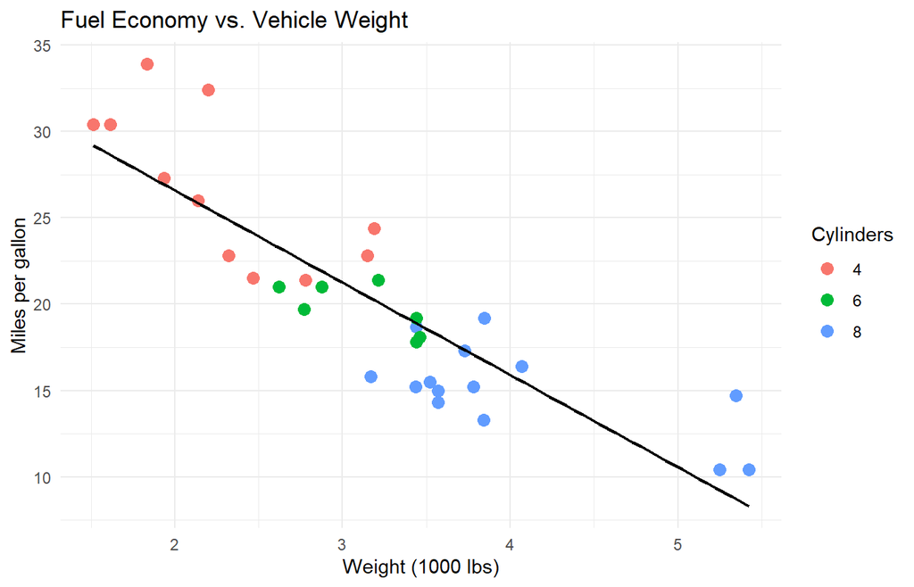

```r
library(ggplot2)
ggplot(mtcars, aes(x = wt, y = mpg, color = factor(cyl))) +
  geom_point(size = 3) +
  geom_smooth(method = "lm", se = FALSE, color = "black", linewidth = 0.8) +
  labs(
    title = "Fuel Economy vs. Vehicle Weight",
    x = "Weight (1000 lbs)",
    y = "Miles per gallon",
    color = "Cylinders"
  ) +
  theme_minimal()
```

## Chunk 3: Fit the model (inline results)

```r
fit <- lm(mpg ~ wt, data = mtcars)
summary(fit)
```

```
##
## Call:
## lm(formula = mpg ~ wt, data = mtcars)
##
## Residuals:
##     Min      1Q  Median      3Q     Max
## -4.5432 -2.3647 -0.1252  1.4096  6.8727
##
## Coefficients:
##             Estimate Std. Error t value Pr(>|t|)
## (Intercept)  37.2851     1.8776  19.858  < 2e-16 ***
## wt           -5.3445     0.5591  -9.559 1.29e-10 ***
## ---
## Signif. codes:  0 '***' 0.001 '**' 0.01 '*' 0.05 '.' 0.1 ' ' 1
##
## Residual standard error: 3.046 on 30 degrees of freedom
## Multiple R-squared:  0.7528, Adjusted R-squared:  0.7446
## F-statistic: 91.38 on 1 and 30 DF,  p-value: 1.294e-10
```

The estimated slope is -5.34 mpg per 1000 lbs, so each additional 1000 lbs of weight is associated with about 5.3 fewer miles per gallon. The model explains 75.3% of the variance in mpg. These numbers are computed inline, so they update automatically if the data change.